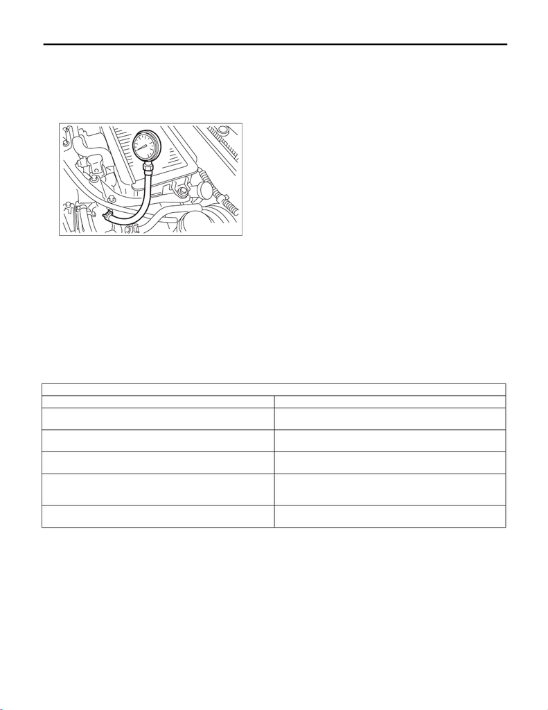

ME(STI)-23

Intake Manifold Vacuum

MECHANICAL

5. Intake Manifold Vacuum

A: INSPECTION

1) Warm up the engine.

2) Disconnect the brake booster vacuum hose from

the intake manifold, and attach the vacuum gauge.

3) Keep the engine at idle speed and read the vac-

uum gauge indication.

NOTE:

Condition of engine inside can be diagnosed by ob-

serving the behavior of the vacuum gauge needle

as described in table below.

Intake manifold vacuum (at idling, A/C OFF):

Standard

–65.3 kPa (–490 mmHg, –19.29 inHg) or

more

4) After inspection, install the related parts in the

reverse order of removal.

ME-00008

Diagnosis of engine condition by inspection of intake manifold vacuum

Vacuum gauge needle behavior Possible engine condition

1. Needle is steady but lower than standard value. This ten-

dency becomes more evident as engine temperature rises.

Leakage around intake manifold gasket, disconnection or dam-

age of vacuum hose

2. Needle intermittently drops to position lower than standard

value.

Leakage around cylinder

3. Needle drops suddenly and intermittently from standard

value.

Sticky valve

4. When engine speed is gradually increased, needle begins to

vibrate rapidly at certain speed, and then vibration increases as

engine speed increases.

Weak or broken valve springs

5. Needle vibrates above and below standard value in narrow

range.

Defective ignition system